# Support Vector Machines(SVMs) Homework 6 HW

Allen Zhu

11/12/2019

## Support Vector Machines(SVMs)

A Support Vector Machine (SVM) is a discriminative classifier formally defined by a separating hyperplane. Given labeled training data, the algorithm outputs an optimal hyperplane which categorizes new examples.

##Homework

1. Choose an appropriate machine learning dataset and use SVM with two different kernels. Campare the results.

The two different kernels performed fairly comparably to each other, the linear kernel has an accuracy of ~.78 whereas the radial kernel has an accuracy of .77 (where a C value of 2 was selected). The linear kernel slightly outperforms its radial counterpart in both the ROC AUC (.83 compared to .81), and the confusion matrix accuracy (.75 compared to .69).

```r
data(PimaIndiansDiabetes2)
```

```r
set.seed(25)

PID <- PimaIndiansDiabetes2


PID[is.na(PID)] = 0

train_size = floor(0.75 * nrow(PID))
train_pos <- sample(seq_len(nrow(PID)), size = train_size)

train_classification <- PID[train_pos, ]
test_classification <- PID[-train_pos, ]

str(PID)
```

```
## 'data.frame':    768 obs. of  9 variables:
##  $ pregnant: num  6 1 8 1 0 5 3 10 2 8 ...
##  $ glucose : num  148 85 183 89 137 116 78 115 197 125 ...
##  $ pressure: num  72 66 64 66 40 74 50 0 70 96 ...
##  $ triceps : num  35 29 0 23 35 0 32 0 45 0 ...
##  $ insulin : num  0 0 0 94 168 0 88 0 543 0 ...
##  $ mass    : num  33.6 26.6 23.3 28.1 43.1 25.6 31 35.3 30.5 0 ...
##  $ pedigree: num  0.627 0.351 0.672 0.167 2.288 ...
##  $ age     : num  50 31 32 21 33 30 26 29 53 54 ...
##  $ diabetes: Factor w/ 2 levels "neg","pos": 2 1 2 1 2 1 2 1 2 2 ...
```

```r
set.seed(205)
control = trainControl(method = "repeatedcv", repeats = 5, classProbs = T, savePredictions = T)

svm = train(diabetes ~ pregnant + glucose + pressure + triceps + insulin + mass + pedigree + age,  data = train_classification, method = "svmLinear", tuneLength = 10, trControl = control)

svm
```

```
## Support Vector Machines with Linear Kernel
##
## 576 samples
##   8 predictor
##   2 classes: 'neg', 'pos'
##
## No pre-processing
## Resampling: Cross-Validated (10 fold, repeated 5 times)
## Summary of sample sizes: 518, 518, 519, 519, 519, 519, ...
## Resampling results:
##
##   Accuracy   Kappa
##   0.7764443  0.4662615
##
## Tuning parameter 'C' was held constant at a value of 1
```

```r
roc(predictor = svm$pred$pos, response = svm$pred$obs)$auc
```

```
## Area under the curve: 0.8317
```

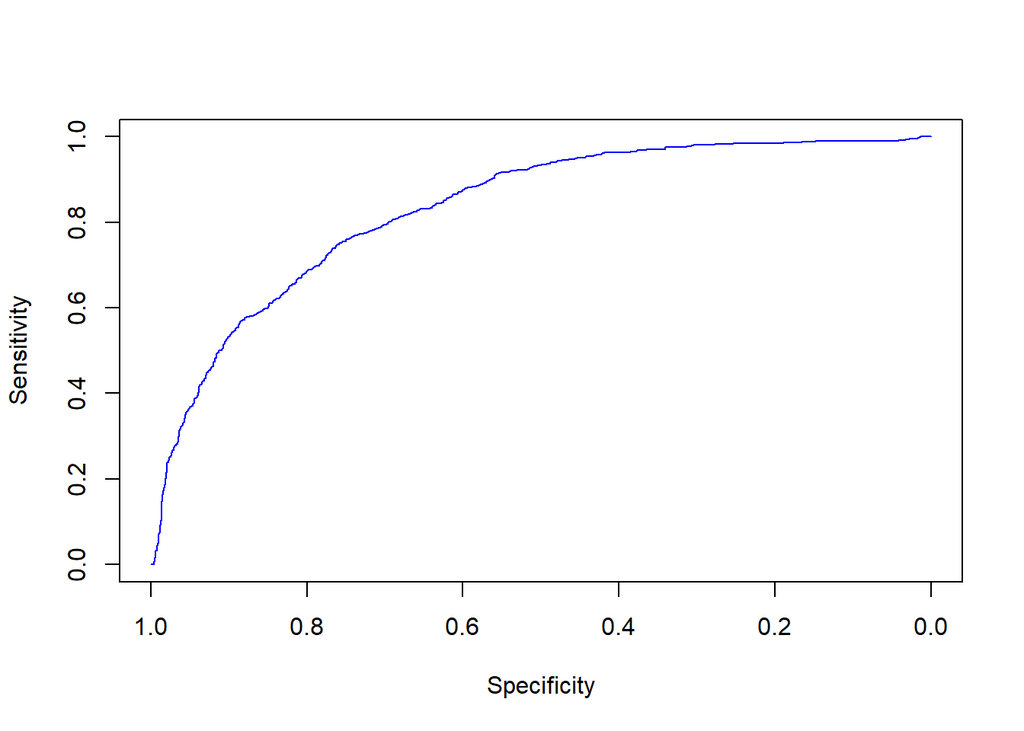

```r
plot(x = roc(predictor = svm$pred$pos, response = svm$pred$obs)$specificities, y = roc(predictor = svm$pred$pos, response = svm$pred$obs)$sensitivities, col= "blue", xlim = c(1, 0), type ="l", ylab = "Sensitivity", xlab = "Specificity")
```

```r
svm_test = predict(svm, newdata = test_classification)

confusionMatrix(svm_test, reference = test_classification$diabetes)
```

```
## Confusion Matrix and Statistics
##
##           Reference
## Prediction neg pos
##        neg 109  39
##        pos   9  35
##
##                Accuracy : 0.75
##                  95% CI : (0.6826, 0.8096)
##     No Information Rate : 0.6146
##     P-Value [Acc > NIR] : 5.072e-05
##
##                   Kappa : 0.4291
##
##  Mcnemar's Test P-Value : 2.842e-05
##
##             Sensitivity : 0.9237
##             Specificity : 0.4730
##          Pos Pred Value : 0.7365
##          Neg Pred Value : 0.7955
##              Prevalence : 0.6146
##          Detection Rate : 0.5677
##    Detection Prevalence : 0.7708
##       Balanced Accuracy : 0.6984
##
##        'Positive' Class : neg
##
```

```r
set.seed(205)
control = trainControl(method = "repeatedcv", repeats = 5, classProbs = T, savePredictions = T)

svm = train(diabetes ~ pregnant + glucose + pressure + triceps + insulin + mass + pedigree + age,  data = train_classification, method = "svmRadial", tuneLength = 10, trControl = control)

svm
```

```
## Support Vector Machines with Radial Basis Function Kernel
##
## 576 samples
##   8 predictor
##   2 classes: 'neg', 'pos'
##
## No pre-processing
## Resampling: Cross-Validated (10 fold, repeated 5 times)
## Summary of sample sizes: 518, 518, 519, 519, 519, 519, ...
## Resampling results across tuning parameters:
##
##   C       Accuracy   Kappa
##     0.25  0.7611204  0.4418547
##     0.50  0.7607814  0.4387213
##     1.00  0.7649433  0.4447713
##     2.00  0.7704850  0.4561910
##     4.00  0.7694624  0.4541237
##     8.00  0.7597820  0.4263282
##    16.00  0.7479907  0.3926116
##    32.00  0.7298417  0.3423924
##    64.00  0.7231990  0.3207981
##   128.00  0.7120915  0.2944001
##
## Tuning parameter 'sigma' was held constant at a value of 0.1353858
## Accuracy was used to select the optimal model using the largest value.
## The final values used for the model were sigma = 0.1353858 and C = 2.
```

```r
roc(predictor = svm$pred$pos, response = svm$pred$obs)$auc
```

```
## Area under the curve: 0.81
```

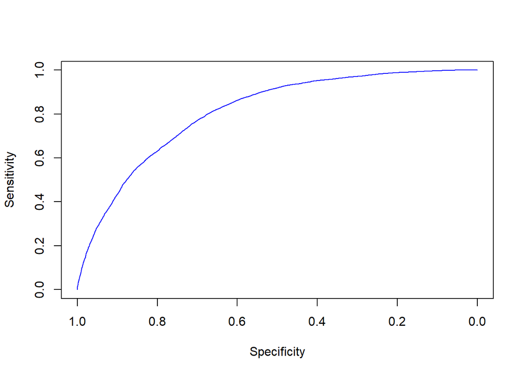

```r
plot(x = roc(predictor = svm$pred$pos, response = svm$pred$obs)$specificities, y = roc(predictor = svm$pred$pos, response = svm$pred$obs)$sensitivities, col= "blue", xlim = c(1, 0), type ="l", ylab = "Sensitivity", xlab = "Specificity")
```

```r
svm_test = predict(svm, newdata = test_classification)

confusionMatrix(svm_test, reference = test_classification$diabetes)
```

```
## Confusion Matrix and Statistics
##
##           Reference
## Prediction neg pos
##        neg  96  37
##        pos  22  37
##
##                Accuracy : 0.6927
##                  95% CI : (0.6222, 0.7571)
##     No Information Rate : 0.6146
##     P-Value [Acc > NIR] : 0.01481
##
##                   Kappa : 0.3259
##
##  Mcnemar's Test P-Value : 0.06836
##
##             Sensitivity : 0.8136
##             Specificity : 0.5000
##          Pos Pred Value : 0.7218
##          Neg Pred Value : 0.6271
##              Prevalence : 0.6146
##          Detection Rate : 0.5000
##    Detection Prevalence : 0.6927
##       Balanced Accuracy : 0.6568
##
##        'Positive' Class : neg
##
```

2. Attempt using SVM after using a previously covered feature selection method. Do the results improve? Explain.

A recursive feature elimination applied to the PimaIndianDiabetes2 (PID) dataset. The method returned 5 variables (glucose, mass, age, pregnant, and pedigree) as the most important variables. Linear and radial SVM kernels were then applied on the dataset selecting only for the aforementioned variables. The results remain more or less unchanged. The linear kernel saw a .01 improvement on the the model accuracy, and a .01 decrease in the confusion matrix accuracy (.77 to .78, and .75 to .74 respectively). The radial kernel performed slighly better compared to its pre-feature selection counterpart, seeing a .01 increase in model accuracy (.77 to .78), and a .05 increase in CM accuracy. It is important to note that C (i.e. the cost of miscalculation) is now lower as well (from 2 to 1). The changes between the two however are small, and the improvements could easily be removed by changing the seed number.

In general, feature selection is not used before attempting SVM. This is because the formula within SVM contains an optimization factor that accounts for all of the variables contained within the dataset. By performing feature selection beforehand, and removing the ‘unimportant’ variables, the optimization parameter within SVM is now weighted more heavily towards the selected features, leading to overfitting, making it worse at predicting the testing set. In the instance seen below, the models didn’t change much because the feature selection still selected 5 out of the 8 predictive variables, and much of the features remain, thus somewhat diluting out the effects overfitting. If a feature selection narrowed the field down to only 2 features, I would expect a larger negative effect on the model’s ability to make predictions on the test set.

```r
set.seed(35)
#define the control
PID <- PimaIndiansDiabetes2
PID[is.na(PID)] = 0
control = rfeControl(functions = caretFuncs, number = 2)

# run the RFE algorithm
results = rfe(PID[,1:8], PID[,9], sizes = c(2,5,9), rfeControl = control, method = "svmRadial")

results
```

```
##
## Recursive feature selection
##
## Outer resampling method: Bootstrapped (2 reps)
##
## Resampling performance over subset size:
##
##  Variables Accuracy  Kappa AccuracySD KappaSD Selected
##          2   0.7447 0.4368   0.003707 0.01338
##          5   0.7610 0.4688   0.041836 0.06836        *
##          8   0.7376 0.4195   0.018753 0.02022
##
## The top 5 variables (out of 5):
##    glucose, mass, age, pregnant, pedigree
```

```r
results$variables
```

| neg | pos | Overall | var | Variables | Resample |
| --- | --- | --- | --- | --- | --- |
| 0.7711709 | 0.7711709 | 0.7711709 | glucose | 8 | Resample1 |
| 0.6791850 | 0.6791850 | 0.6791850 | age | 8 | Resample1 |
| 0.6748737 | 0.6748737 | 0.6748737 | mass | 8 | Resample1 |
| 0.6253918 | 0.6253918 | 0.6253918 | pedigree | 8 | Resample1 |
| 0.6251152 | 0.6251152 | 0.6251152 | pregnant | 8 | Resample1 |
| 0.5654619 | 0.5654619 | 0.5654619 | triceps | 8 | Resample1 |
| 0.5579015 | 0.5579015 | 0.5579015 | pressure | 8 | Resample1 |
| 0.5445141 | 0.5445141 | 0.5445141 | insulin | 8 | Resample1 |
| 0.7711709 | 0.7711709 | 0.7711709 | glucose | 5 | Resample1 |
| 0.6791850 | 0.6791850 | 0.6791850 | age | 5 | Resample1 |

[output cut: 20 more lines]

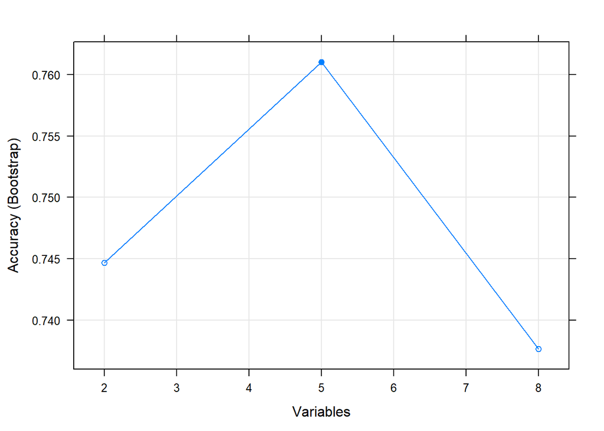

```r
plot(results, type=c("g", "o"))
```

```r
set.seed(205)
control = trainControl(method = "repeatedcv", repeats = 5, classProbs = T, savePredictions = T)

svm = train(diabetes ~ pregnant + glucose  + mass + pedigree + age,  data = train_classification, method = "svmLinear", tuneLength = 10, trControl = control)

svm
```

```
## Support Vector Machines with Linear Kernel
##
## 576 samples
##   5 predictor
##   2 classes: 'neg', 'pos'
##
## No pre-processing
## Resampling: Cross-Validated (10 fold, repeated 5 times)
## Summary of sample sizes: 518, 518, 519, 519, 519, 519, ...
## Resampling results:
##
##   Accuracy  Kappa
##   0.782016  0.480409
##
## Tuning parameter 'C' was held constant at a value of 1
```

```r
roc(predictor = svm$pred$pos, response = svm$pred$obs)$auc
```

```
## Area under the curve: 0.8363
```

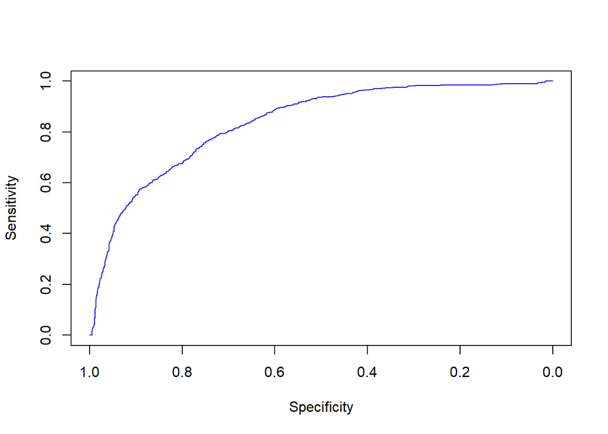

```r
plot(x = roc(predictor = svm$pred$pos, response = svm$pred$obs)$specificities, y = roc(predictor = svm$pred$pos, response = svm$pred$obs)$sensitivities, col= "blue", xlim = c(1, 0), type ="l", ylab = "Sensitivity", xlab = "Specificity")
```

```r
svm_test = predict(svm, newdata = test_classification)

confusionMatrix(svm_test, reference = test_classification$diabetes)
```

```
## Confusion Matrix and Statistics
##
##           Reference
## Prediction neg pos
##        neg 108  39
##        pos  10  35
##
##                Accuracy : 0.7448
##                  95% CI : (0.677, 0.8048)
##     No Information Rate : 0.6146
##     P-Value [Acc > NIR] : 9.620e-05
##
##                   Kappa : 0.4188
##
##  Mcnemar's Test P-Value : 6.334e-05
##
##             Sensitivity : 0.9153
##             Specificity : 0.4730
##          Pos Pred Value : 0.7347
##          Neg Pred Value : 0.7778
##              Prevalence : 0.6146
##          Detection Rate : 0.5625
##    Detection Prevalence : 0.7656
##       Balanced Accuracy : 0.6941
##
##        'Positive' Class : neg
##
```

```r
set.seed(205)
control = trainControl(method = "repeatedcv", repeats = 5, classProbs = T, savePredictions = T)

svm = train(diabetes ~ pregnant + glucose  + mass + pedigree + age,  data = train_classification, method = "svmRadial", tuneLength = 10, trControl = control)

svm
```

```
## Support Vector Machines with Radial Basis Function Kernel
##
## 576 samples
##   5 predictor
##   2 classes: 'neg', 'pos'
##
## No pre-processing
## Resampling: Cross-Validated (10 fold, repeated 5 times)
## Summary of sample sizes: 518, 518, 519, 519, 519, 519, ...
## Resampling results across tuning parameters:
##
##   C       Accuracy   Kappa
##     0.25  0.7750406  0.4677233
##     0.50  0.7781624  0.4747758
##     1.00  0.7837338  0.4886779
##     2.00  0.7802728  0.4814139
##     4.00  0.7671200  0.4470148
##     8.00  0.7570345  0.4198314
##    16.00  0.7427150  0.3807628
##    32.00  0.7333442  0.3543890
##    64.00  0.7308635  0.3355737
##   128.00  0.7295206  0.3312474
##
## Tuning parameter 'sigma' was held constant at a value of 0.2528948
## Accuracy was used to select the optimal model using the largest value.
## The final values used for the model were sigma = 0.2528948 and C = 1.
```

```r
roc(predictor = svm$pred$pos, response = svm$pred$obs)$auc
```

```
## Area under the curve: 0.8148
```

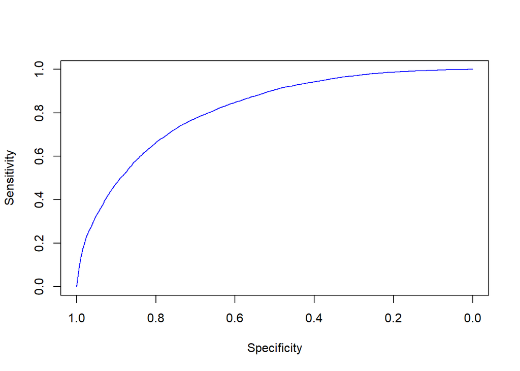

```r
plot(x = roc(predictor = svm$pred$pos, response = svm$pred$obs)$specificities, y = roc(predictor = svm$pred$pos, response = svm$pred$obs)$sensitivities, col= "blue", xlim = c(1, 0), type ="l", ylab = "Sensitivity", xlab = "Specificity")
```

```r
svm_test = predict(svm, newdata = test_classification)

confusionMatrix(svm_test, reference = test_classification$diabetes)
```

```
## Confusion Matrix and Statistics
##
##           Reference
## Prediction neg pos
##        neg 106  37
##        pos  12  37
##
##                Accuracy : 0.7448
##                  95% CI : (0.677, 0.8048)
##     No Information Rate : 0.6146
##     P-Value [Acc > NIR] : 9.62e-05
##
##                   Kappa : 0.4251
##
##  Mcnemar's Test P-Value : 0.0006068
##
##             Sensitivity : 0.8983
##             Specificity : 0.5000
##          Pos Pred Value : 0.7413
##          Neg Pred Value : 0.7551
##              Prevalence : 0.6146
##          Detection Rate : 0.5521
##    Detection Prevalence : 0.7448
##       Balanced Accuracy : 0.6992
##
##        'Positive' Class : neg
##
```